# Raport do projektu nr 2 - faza 1

Grzegorz Bajor, Rafał Grądziel, Michał Walczyński

15 maja 2016

### Przetworzenie danych

Na początku zostają wczytaną z pliku wszystkie dane i wybrane tylko te dotyczące banku BZWBK.

```r
dane <- read.csv2("applica_data_sample.csv", encoding = "utf8")

BZWBK <- dane[dane["source"] == "https://www.facebook.com/bzwbk", ]
```

Następnie zajmować się będziemy korektą i analizą wpisów, dlatego z danych wybieramy tylko wpisy.

```r
wpisy <- as.character(data.frame(lapply(BZWBK[,9], as.character), stringsAsFactors=FALSE))
```

Do wykonania konwersji potrzebne będzie poprawienie kodowania polskich znaków.

```r
wpisy2 <- iconv(wpisy, from = "utf8", to = "windows-1250")
```

Następnie łączymy wszystkie wpisy słowem nie występującym w żadnym z wpisów i działamy konwersją na jednym dużym wpisie.

```r
wp <- stri_paste(wpisy2, collapse = " separator ")
```

```r
korekta <- POST("https://ec2-54-194-28-130.eu-west-1.compute.amazonaws.com/ams-ws-nlp/rest/spell/single",
                body = list(message = list(body = wp), token="2$zgITnb02!lV"),
                add_headers("Content-Type" = "application/json"), encode = "json")

wpisy_kor <- content(korekta, "parsed")
```

Na koniec, dzielimy otrzymany wpis po korekcie do pierwotnej formy.

```r
  wpisy <- unlist(stri_split_regex(wpisy_kor$output, " separator "))
```

Na każdym utworzonym wpisie po korekcie działamy analizą morfologiczną. Wyłuskiwać z niej będziemy, liczbę części mowy we wpisie oraz wszystkie rzeczowniki w formie bazowej. Znajdować będziemy też te rzeczowniki bez powtórzeń.

```r
len <- length(wpisy)
t <- vector("list", len)
nouns <- vector("list", len)
unikalne <- vector("list", len)

for(j in 1 : len){
  nlp <- POST("https://ec2-54-194-28-130.eu-west-1.compute.amazonaws.com/ams-ws-nlp/rest/nlp/single",
              body = list(message=list(body=wpisy[j]), token="2$zgITnb02!lV"),
              add_headers("Content-Type" = "application/json"), encode = "json")

  x <- content(nlp, "parsed")

  lenx <- length(x$elements)

  s <- vector("character", lenx)
  czesc_zdania <- vector("character", lenx)

  i = 1
  repeat{
    if(i > lenx){
      break
    }

    if(is.null(x$elements[[i]]$cTag)){
      break
    }

    s[i] <- x$elements[[i]]$cTag

    czesc_zdania[i] <- x$elements[[i]]$base

    i = i + 1

  }

  t[[j]] <- s[1:(i-1)]
  nouns[[j]] <- czesc_zdania[s == "Noun"]
  unikalne[[j]] <- unique(nouns[[j]])

}
```

### Analiza rzeczowników.

Nasza analiza w pierwszej fazie skupiona jest wokół analizy rzeczowników. Wpierw przeanalizujmy 2 histogramy: jeden dla wszystkich wyrazów w danym wpisie, drugi zliczający częstość wystąpień rzeczowniki.

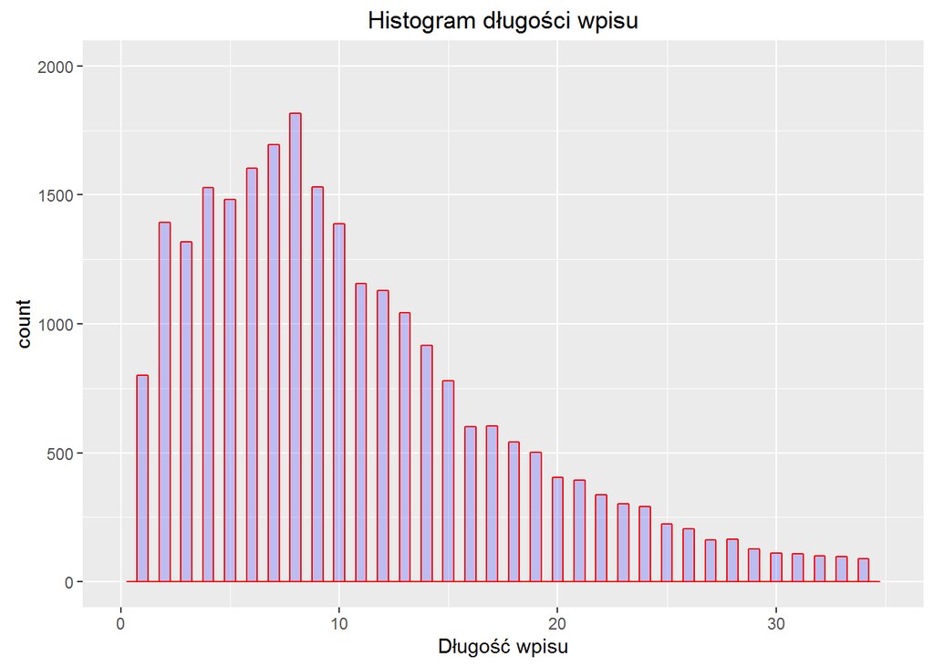

```r
qplot(dane$liczba_wyr,
      geom="histogram",
      binwidth = 0.5,
      main = "Histogram długości wpisu",
      xlab = "Długość wpisu",
      fill=I("blue"),
      col=I("red"),
      alpha=I(.2),
      xlim=c(0,35),
      ylim=c(0,2000))
```

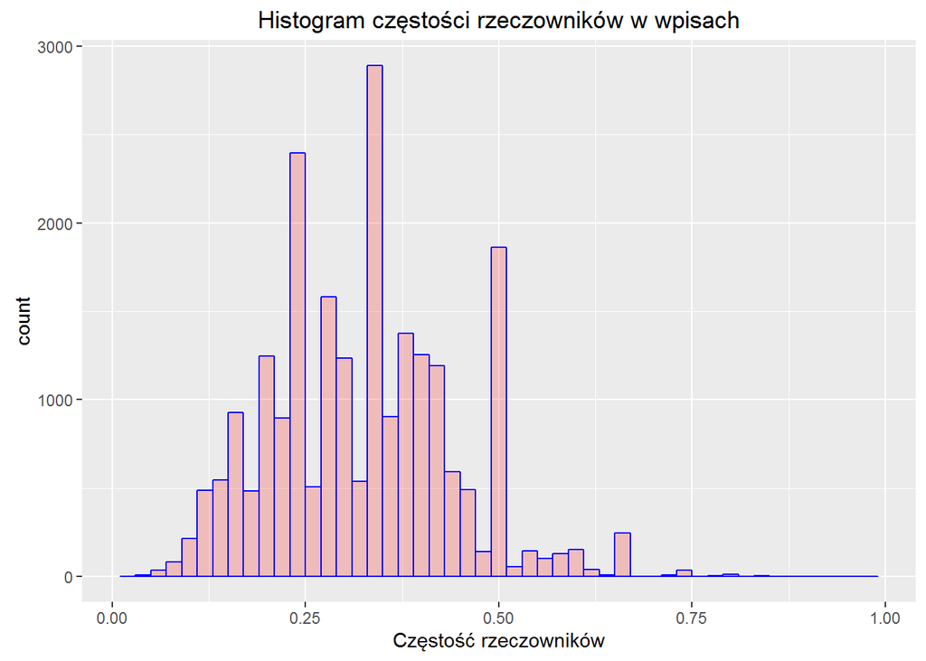

```r
qplot(czestosc,
      geom="histogram",
      binwidth = 0.02,
      main = "Histogram częstości rzeczowników w wpisach",
      xlab = "Częstość rzeczowników",
      fill=I("red"),
      col=I("blue"),
      alpha=I(.2),
      xlim=c(0.01,0.99))
```

Jaki widzimy duża masa “prawdopodobieństwa” jest skupiona między 20% - 50%, co znaczy, że przynajmniej co piąte słowo w wyrazie jest rzeczownikiem. Tak więc, wykresy pozwalają uznać za sensowną dalszą próbe analizy rzeczowników w poszukiwaniu trendów.

Teraz policzmy ile razy dany rzeczownik pojawią się we wszystkich wpisach. Dodatkowo zliczmy również ile razy ustalony rzeczownik występuje we wpisach, przy czym jeśli występuje w pewnym wpisie więcej niż raz, to i tak nadajemu mu liczbę wystąpien równą jeden ( binarne przyporządkowanie wewnątrz wpisów ). Sens takich rozważań ujawni się później.

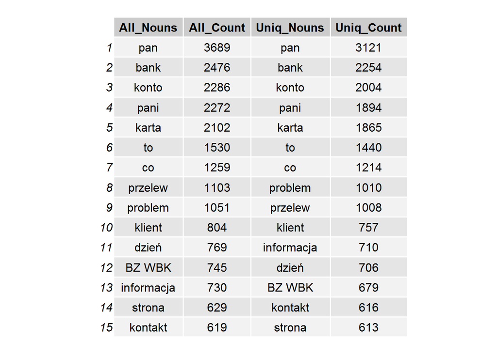

```r
tabela <- cbind(All_Nouns=names(zagr_order)[1:15],All_Count=zagr_order[1:15],Uniq_Nouns=names(zagr_order_istn)[1:15],Uniq_Count=zagr_order_istn[1:15] )
rownames(tabela)=1:15
grid.table(tabela)
```

Jak widzimy w przypadku zliczania na całym horyzoncie czasowym te wyniki są do siebie podobne. Jednakże, skoro liczba rzeczowników ( unikalna wewnątrz postów ), mówi nam w ilu postach wystąpił. Jeśli ogólną liczbę rzeczoników unormujemy liczbą unikalnych to otrzymamy częstość wystąpień danego wyrazu. Dodatkowo przy zwężaniu horyzontu czasowego, możemy rozpoznawać pewne “trendy” dzięki znajomości częstotliwości wystąpień danego wyrazu. Przykładowo:

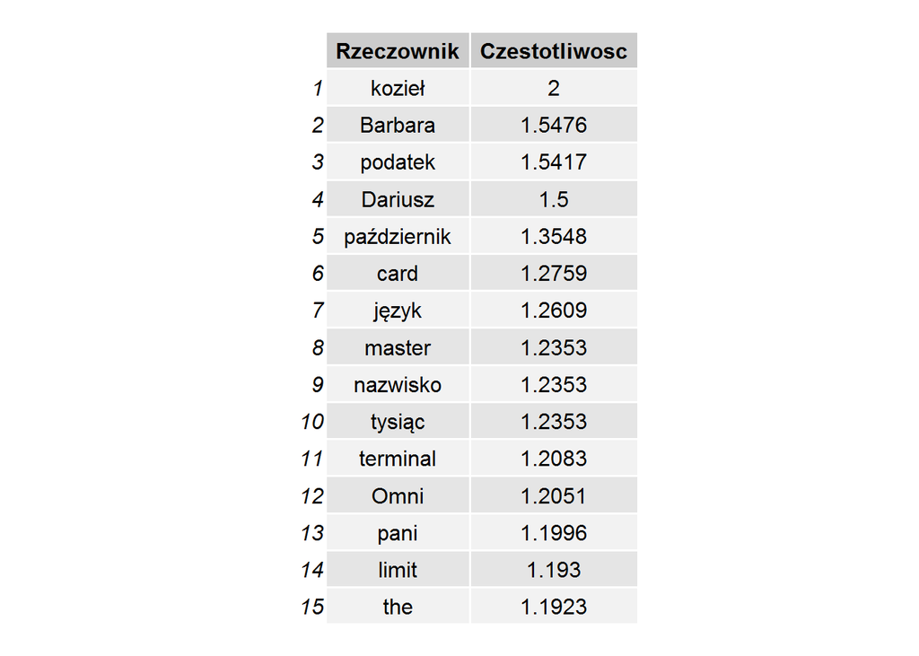

```r
ile_razy_na_post <- zagr_order/zagr_order_istn[names(zagr_order)]
ile_razy_na_post <- ile_razy_na_post[zagr_order_istn[names(zagr_order)]>10]
ile_razy_order <- ile_razy_na_post[order(ile_razy_na_post,decreasing = TRUE)]
tabela <- cbind(Rzeczownik=names(ile_razy_order)[1:15],Czestotliwosc=round((ile_razy_order)[1:15],4) )
rownames(tabela)=1:15
grid.table(tabela)
```

Pojawiło się dużo słów, które w rankingu najpopularniejszych się nie pojawiały. Sprawdźmy kilka z nich - jakie opisują trendy.

```r
tabela <- cbind(Rzeczownik=c("październik","kozieł"),Wystapienia=c(zagregowane[names(zagregowane_istn)=="październik"],zagregowane[names(zagregowane_istn)=="kozieł"]),Unikalne=c(zagregowane_istn[names(zagregowane_istn)=="październik"],zagregowane_istn[names(zagregowane_istn)=="kozieł"]) )
kable(tabela)
```

|  | Rzeczownik | Wystapienia | Unikalne |
| --- | --- | --- | --- |
| październik | październik | 42 | 31 |
| kozieł | kozieł | 46 | 23 |

Oraz wybierzmy reprezentatywny wpis związany z tym rzeczownikiem:

```r
load("bzwbk")
load("nouns")

suma_wystapien <- function(wyraz){
  sapply(lapply(nouns, "==", wyraz), sum)
}
wpisy_z_wyrazem <- function(wyraz){
  BZWBK[which(suma_wystapien(wyraz) != 0),9]
}

koziel <- wpisy_z_wyrazem("kozieł")
pazdziernik <- wpisy_z_wyrazem("październik")
```

Wpis związany z rzeczownikiem *październik*:

```
## [1] "Chcielibyśmy Was poinformować o planowanych przerwach w dostępie do usług:\n\n- transakcje złożone w BZWBK24 (w tym Przelew24) zlecone po godz. 22.00 w piątek (18 października), zostaną zrealizowane w niedzielę (20 października) po godz. 19.00,\n\n- w niedzielę (20 października), od godz. 4.…
```

Wpis związany z rzeczownikiem *kozieł*:

```
## [1] "Dzień dobry Państwo złodziejstwo WBK Bank Zachodni ,\n\nUczciwi Państwo Barbara i Dariusz Kozieł, \n\npoproszą o umowę na prowadzenie rachunku oraz wzory podpisów zawartą \npomiędzy Bank Zachodni WBK a \nBarbara, Dariusz Kozieł (właściwe dane zamieszkania) i nie wyłudzone przez \nWBK Bank Za…
```